# Capstone - Fintech & BNPL Investor Interest

by Noel McCann from Dream Team (Team 2)

[figure not shown]

Based on the **StartUp Investments (Crunchbase) dataset** - Information about startup companies and investment via Crunchbase https://www.kaggle.com/arindam235/startup-investments-crunchbase

### **Introduction to the dataset**

**StartUp Investments (Crunchbase):** https://www.kaggle.com/arindam235/startup-investments-crunchbase

- The dataset used for this analysis was downloaded from Kaggle but the source of the data is from Crunchbase. The site contains financial information and funding rounds for private and public companies involved in services such as payments and BNPL.

**The dataset consists financial data relating to investments in startups. This data includes:**

- startup name
- url
- market category
- status (operating, acquired, closed)
- location: country, city, region
- funding: total funding in usd, type of funding (including, but not limited to, seed, angel, debt taken, venture capital, & funding rounds)

The goal of this workbook is to provide a financial analysis on companies in the fintech space. We specifically concentrated on companies that specialize in finance, payments, and BNPL to see where companies such as Afterpay and Klarna have performed in the space, and how Square stands to benefit from entering this market.

```python
# Importing necessary Python packages
import sys
!{sys.executable} -m pip install numpy
import numpy as np
import pandas as pd
import matplotlib.pyplot as plt
import seaborn as sns
import warnings
warnings.filterwarnings("ignore")
```

### **Reading the Crunchbase Data Set**

```python
pd.options.mode.chained_assignment = None
pd.set_option('display.max_column',None)
```

```python
investments = pd.read_csv('investments_VC.csv', encoding = "ISO-8859-1")
```

### **Focusing our study: Filtering and Identifying**

Given Crunchbase's large amount of data, it would be overwhelming to go through the entire dataset. Given our goal to financially analyze the performance of private and public fintech companies, filtering needs to be done to clean up the dataset. First, we took a look at the structure and brief contents of the data, such as the columns. Afterwards, we selected a subset of columns relevant to our focus on Fintech.

```python
investments.head()

# for a quick glance at the material's first five rows.
```

|  | permalink | name | homepage_url | category_list | market | funding_total_usd | status | country_code | state_code | region | city | funding_rounds | founded_at | founded_month | founded_quarter | founded_year | first_funding_at | last_funding_at | seed | venture | equity_crowdfunding | undisclosed | convertible_note | debt_financing | angel | grant | private_equity | post_ipo_equity | post_ipo_debt | … |
| --- | --- | --- | --- | --- | --- | --- | --- | --- | --- | --- | --- | --- | --- | --- | --- | --- | --- | --- | --- | --- | --- | --- | --- | --- | --- | --- | --- | --- | --- | --- |
| 0 | /organization/waywire | #waywire | http://www.waywire.com | \|Entertainment\|Politics\|Social Media\|News\| | News | 17,50,000 | acquired | USA | NY | New York City | New York | 1.0 | 2012-06-01 | 2012-06 | 2012-Q2 | 2012.0 | 2012-06-30 | 2012-06-30 | 1750000.0 | 0.0 | 0.0 | 0.0 | 0.0 | 0.0 | 0.0 | 0.0 | 0.0 | 0.0 | 0.0 | … |
| 1 | /organization/tv-communications | &TV Communications | http://enjoyandtv.com | \|Games\| | Games | 40,00,000 | operating | USA | CA | Los Angeles | Los Angeles | 2.0 | NaN | NaN | NaN | NaN | 2010-06-04 | 2010-09-23 | 0.0 | 4000000.0 | 0.0 | 0.0 | 0.0 | 0.0 | 0.0 | 0.0 | 0.0 | 0.0 | 0.0 | … |
| 2 | /organization/rock-your-paper | 'Rock' Your Paper | http://www.rockyourpaper.org | \|Publishing\|Education\| | Publishing | 40,000 | operating | EST | NaN | Tallinn | Tallinn | 1.0 | 2012-10-26 | 2012-10 | 2012-Q4 | 2012.0 | 2012-08-09 | 2012-08-09 | 40000.0 | 0.0 | 0.0 | 0.0 | 0.0 | 0.0 | 0.0 | 0.0 | 0.0 | 0.0 | 0.0 | … |
| 3 | /organization/in-touch-network | (In)Touch Network | http://www.InTouchNetwork.com | \|Electronics\|Guides\|Coffee\|Restaurants\|Music\|i... | Electronics | 15,00,000 | operating | GBR | NaN | London | London | 1.0 | 2011-04-01 | 2011-04 | 2011-Q2 | 2011.0 | 2011-04-01 | 2011-04-01 | 1500000.0 | 0.0 | 0.0 | 0.0 | 0.0 | 0.0 | 0.0 | 0.0 | 0.0 | 0.0 | 0.0 | … |
| 4 | /organization/r-ranch-and-mine | -R- Ranch and Mine | NaN | \|Tourism\|Entertainment\|Games\| | Tourism | 60,000 | operating | USA | TX | Dallas | Fort Worth | 2.0 | 2014-01-01 | 2014-01 | 2014-Q1 | 2014.0 | 2014-08-17 | 2014-09-26 | 0.0 | 0.0 | 60000.0 | 0.0 | 0.0 | 0.0 | 0.0 | 0.0 | 0.0 | 0.0 | 0.0 | … |

```python
investments.info()

# using the Pandas info function, we get a summary of the dataframe's contents,
# eg. dtypes, columns and their names, entries and non-null values.
```

```
<class 'pandas.core.frame.DataFrame'>
RangeIndex: 54294 entries, 0 to 54293
Data columns (total 39 columns):
 #   Column                Non-Null Count  Dtype
---  ------                --------------  -----
 0   permalink             49438 non-null  object
 1   name                  49437 non-null  object
 2   homepage_url          45989 non-null  object
 3   category_list         45477 non-null  object
 4    market               45470 non-null  object
 5    funding_total_usd    49438 non-null  object
 6   status                48124 non-null  object
 7   country_code          44165 non-null  object
 8   state_code            30161 non-null  object
 9   region                44165 non-null  object
```

[output cut: 31 more lines]

```python
investments.describe()
# for some statistics on the dataframe's non-null entries (49k+) as well as its the mean, min, max values etc. - how the data is distributed.
```

|  | funding_rounds | founded_year | seed | venture | equity_crowdfunding | undisclosed | convertible_note | debt_financing | angel | grant | private_equity | post_ipo_equity | post_ipo_debt | secondary_market | product_crowdfunding | round_A | round_B | round_C | round_D | round_E | round_F | round_G | round_H |
| --- | --- | --- | --- | --- | --- | --- | --- | --- | --- | --- | --- | --- | --- | --- | --- | --- | --- | --- | --- | --- | --- | --- | --- |
| count | 49438.000000 | 38482.000000 | 4.943800e+04 | 4.943800e+04 | 4.943800e+04 | 4.943800e+04 | 4.943800e+04 | 4.943800e+04 | 4.943800e+04 | 4.943800e+04 | 4.943800e+04 | 4.943800e+04 | 4.943800e+04 | 4.943800e+04 | 4.943800e+04 | 4.943800e+04 | 4.943800e+04 | 4.943800e+04 | 4.943800e+04 | 4.943800e+04 | 4.943800e+04 | 4.943800e+04 | 4.943800e+04 |
| mean | 1.696205 | 2007.359129 | 2.173215e+05 | 7.501051e+06 | 6.163322e+03 | 1.302213e+05 | 2.336410e+04 | 1.888157e+06 | 6.541898e+04 | 1.628453e+05 | 2.074286e+06 | 6.088736e+05 | 4.434360e+05 | 3.845592e+04 | 7.074227e+03 | 1.243955e+06 | 1.492891e+06 | 1.205356e+06 | 7.375261e+05 | 3.424682e+05 | 1.697692e+05 | 5.767067e+04 | 1.423197e+04 |
| std | 1.294213 | 7.579203 | 1.056985e+06 | 2.847112e+07 | 1.999048e+05 | 2.981404e+06 | 1.432046e+06 | 1.382046e+08 | 6.582908e+05 | 5.612088e+06 | 3.167231e+07 | 2.678348e+07 | 3.428169e+07 | 3.864461e+06 | 4.282166e+05 | 5.531974e+06 | 7.472704e+06 | 7.993592e+06 | 9.815218e+06 | 5.406915e+06 | 6.277905e+06 | 5.252312e+06 | 2.716865e+06 |
| min | 1.000000 | 1902.000000 | 0.000000e+00 | 0.000000e+00 | 0.000000e+00 | 0.000000e+00 | 0.000000e+00 | 0.000000e+00 | 0.000000e+00 | 0.000000e+00 | 0.000000e+00 | 0.000000e+00 | 0.000000e+00 | 0.000000e+00 | 0.000000e+00 | 0.000000e+00 | 0.000000e+00 | 0.000000e+00 | 0.000000e+00 | 0.000000e+00 | 0.000000e+00 | 0.000000e+00 | 0.000000e+00 |
| 25% | 1.000000 | 2006.000000 | 0.000000e+00 | 0.000000e+00 | 0.000000e+00 | 0.000000e+00 | 0.000000e+00 | 0.000000e+00 | 0.000000e+00 | 0.000000e+00 | 0.000000e+00 | 0.000000e+00 | 0.000000e+00 | 0.000000e+00 | 0.000000e+00 | 0.000000e+00 | 0.000000e+00 | 0.000000e+00 | 0.000000e+00 | 0.000000e+00 | 0.000000e+00 | 0.000000e+00 | 0.000000e+00 |
| 50% | 1.000000 | 2010.000000 | 0.000000e+00 | 0.000000e+00 | 0.000000e+00 | 0.000000e+00 | 0.000000e+00 | 0.000000e+00 | 0.000000e+00 | 0.000000e+00 | 0.000000e+00 | 0.000000e+00 | 0.000000e+00 | 0.000000e+00 | 0.000000e+00 | 0.000000e+00 | 0.000000e+00 | 0.000000e+00 | 0.000000e+00 | 0.000000e+00 | 0.000000e+00 | 0.000000e+00 | 0.000000e+00 |
| 75% | 2.000000 | 2012.000000 | 2.500000e+04 | 5.000000e+06 | 0.000000e+00 | 0.000000e+00 | 0.000000e+00 | 0.000000e+00 | 0.000000e+00 | 0.000000e+00 | 0.000000e+00 | 0.000000e+00 | 0.000000e+00 | 0.000000e+00 | 0.000000e+00 | 0.000000e+00 | 0.000000e+00 | 0.000000e+00 | 0.000000e+00 | 0.000000e+00 | 0.000000e+00 | 0.000000e+00 | 0.000000e+00 |
| max | 18.000000 | 2014.000000 | 1.300000e+08 | 2.351000e+09 | 2.500000e+07 | 2.924328e+08 | 3.000000e+08 | 3.007950e+10 | 6.359026e+07 | 7.505000e+08 | 3.500000e+09 | 4.700000e+09 | 5.800000e+09 | 6.806116e+08 | 7.200000e+07 | 3.190000e+08 | 5.420000e+08 | 4.900000e+08 | 1.200000e+09 | 4.000000e+08 | 1.060000e+09 | 1.000000e+09 | 6.000000e+08 |

```python
# Choosing the most suitable columns for our study
investments = investments[['name', ' market ',
       ' funding_total_usd ', 'status', 'country_code', 'region',
        'state_code', 'funding_rounds', 'founded_at','first_funding_at',
       'last_funding_at', 'seed', 'venture', 'equity_crowdfunding',
       'undisclosed', 'convertible_note', 'debt_financing', 'angel', 'grant',
       'private_equity', 'post_ipo_equity', 'post_ipo_debt',
       'secondary_market', 'product_crowdfunding', 'round_A', 'round_B',
       'round_C', 'round_D', 'round_E', 'round_F', 'round_G', 'round_H']]
```

```python
# Further limiting our dataset to only financial startups and the payments industry
investments = investments.set_index(' market ')
```

```python
# Using the Pandas loc function to access specific labelled rows and columns.
# Note we are excluding cryptocurrency, e-commerce, and legacy finance companies (ie Banks or Venture funds).
investments = investments.loc[[ ' Credit ', ' Credit Cards ', ' Finance Technology ',
                                ' Financial Services ', ' Mobile Payments ',
                               ' Monetization ', ' P2P Money Transfer ',
                                ' Payments ', ' Social Commerce '
], :]
```

```python
# For a random sample from the selected subset

investments.sample(10)
```

| market | name | funding_total_usd | status | country_code | region | state_code | funding_rounds | founded_at | first_funding_at | last_funding_at | seed | venture | equity_crowdfunding | undisclosed | convertible_note | debt_financing | angel | grant | private_equity | post_ipo_equity | post_ipo_debt | secondary_market | product_crowdfunding | round_A | round_B | round_C | round_D | round_E | round_F | … |
| --- | --- | --- | --- | --- | --- | --- | --- | --- | --- | --- | --- | --- | --- | --- | --- | --- | --- | --- | --- | --- | --- | --- | --- | --- | --- | --- | --- | --- | --- | --- |
| Finance Technology | Snowflake Technologies | 60,00,000 | operating | USA | Memphis | TN | 1.0 | NaN | 2006-07-12 | 2006-07-12 | 0.0 | 6000000.0 | 0.0 | 0.0 | 0.0 | 0.0 | 0.0 | 0.0 | 0.0 | 0.0 | 0.0 | 0.0 | 0.0 | 0.0 | 0.0 | 0.0 | 0.0 | 0.0 | 0.0 | … |
| Payments | Paymetric | 3,05,00,000 | operating | USA | Atlanta | GA | 6.0 | 1998-01-01 | 2005-01-26 | 2013-08-29 | 0.0 | 30500000.0 | 0.0 | 0.0 | 0.0 | 0.0 | 0.0 | 0.0 | 0.0 | 0.0 | 0.0 | 0.0 | 0.0 | 7000000.0 | 8000000.0 | 0.0 | 0.0 | 0.0 | 0.0 | … |
| Finance Technology | Derivative Path, Inc. | - | operating | USA | SF Bay Area | CA | 2.0 | 2013-05-13 | 2013-05-01 | 2013-11-01 | 0.0 | 0.0 | 0.0 | 0.0 | 0.0 | 0.0 | 0.0 | 0.0 | 0.0 | 0.0 | 0.0 | 0.0 | 0.0 | 0.0 | 0.0 | 0.0 | 0.0 | 0.0 | 0.0 | … |
| Social Commerce | SNAPCARD | 15,60,000 | operating | USA | SF Bay Area | CA | 2.0 | 2013-11-19 | 2013-12-01 | 2014-10-06 | 1500000.0 | 60000.0 | 0.0 | 0.0 | 0.0 | 0.0 | 0.0 | 0.0 | 0.0 | 0.0 | 0.0 | 0.0 | 0.0 | 0.0 | 0.0 | 0.0 | 0.0 | 0.0 | 0.0 | … |
| Financial Services | CTQuan | 40,00,000 | operating | CHN | Beijing | NaN | 1.0 | 2011-01-01 | 2014-06-13 | 2014-06-13 | 0.0 | 4000000.0 | 0.0 | 0.0 | 0.0 | 0.0 | 0.0 | 0.0 | 0.0 | 0.0 | 0.0 | 0.0 | 0.0 | 0.0 | 0.0 | 0.0 | 0.0 | 0.0 | 0.0 | … |
| Financial Services | Dengi Online | 20,00,000 | operating | RUS | St. Petersburg | NaN | 1.0 | NaN | 2012-12-31 | 2012-12-31 | 0.0 | 0.0 | 0.0 | 2000000.0 | 0.0 | 0.0 | 0.0 | 0.0 | 0.0 | 0.0 | 0.0 | 0.0 | 0.0 | 0.0 | 0.0 | 0.0 | 0.0 | 0.0 | 0.0 | … |
| Payments | enStage | 15,00,000 | operating | USA | SF Bay Area | CA | 1.0 | 1999-01-01 | 2009-05-06 | 2009-05-06 | 0.0 | 1500000.0 | 0.0 | 0.0 | 0.0 | 0.0 | 0.0 | 0.0 | 0.0 | 0.0 | 0.0 | 0.0 | 0.0 | 0.0 | 0.0 | 0.0 | 0.0 | 0.0 | 0.0 | … |
| Financial Services | Cascade Financial Technology Corp | 2,17,500 | operating | NaN | NaN | NaN | 2.0 | NaN | 2012-12-15 | 2013-11-05 | 217500.0 | 0.0 | 0.0 | 0.0 | 0.0 | 0.0 | 0.0 | 0.0 | 0.0 | 0.0 | 0.0 | 0.0 | 0.0 | 0.0 | 0.0 | 0.0 | 0.0 | 0.0 | 0.0 | … |
| Payments | LendFriend | - | operating | USA | SF Bay Area | CA | 1.0 | 2010-01-01 | 2011-10-01 | 2011-10-01 | 0.0 | 0.0 | 0.0 | 0.0 | 0.0 | 0.0 | 0.0 | 0.0 | 0.0 | 0.0 | 0.0 | 0.0 | 0.0 | 0.0 | 0.0 | 0.0 | 0.0 | 0.0 | 0.0 | … |
| Social Commerce | MoboFree | - | operating | LTU | Vilnius | NaN | 1.0 | NaN | 2014-02-12 | 2014-02-12 | 0.0 | 0.0 | 0.0 | 0.0 | 0.0 | 0.0 | 0.0 | 0.0 | 0.0 | 0.0 | 0.0 | 0.0 | 0.0 | 0.0 | 0.0 | 0.0 | 0.0 | 0.0 | 0.0 | … |

```python
investments.head()
```

| market | name | funding_total_usd | status | country_code | region | state_code | funding_rounds | founded_at | first_funding_at | last_funding_at | seed | venture | equity_crowdfunding | undisclosed | convertible_note | debt_financing | angel | grant | private_equity | post_ipo_equity | post_ipo_debt | secondary_market | product_crowdfunding | round_A | round_B | round_C | round_D | round_E | round_F | … |
| --- | --- | --- | --- | --- | --- | --- | --- | --- | --- | --- | --- | --- | --- | --- | --- | --- | --- | --- | --- | --- | --- | --- | --- | --- | --- | --- | --- | --- | --- | --- |
| Credit | Alekto | 50,000 | closed | USA | Raleigh | NC | 1.0 | 2012-07-01 | 2012-08-27 | 2012-08-27 | 50000.0 | 0.0 | 0.0 | 0.0 | 0.0 | 0.0 | 0.0 | 0.0 | 0.0 | 0.0 | 0.0 | 0.0 | 0.0 | 0.0 | 0.0 | 0.0 | 0.0 | 0.0 | 0.0 | … |
| Credit | ApnaPaisa | 1,72,00,000 | operating | IND | Mumbai | NaN | 2.0 | 2007-01-01 | 2007-01-30 | 2007-12-01 | 0.0 | 17200000.0 | 0.0 | 0.0 | 0.0 | 0.0 | 0.0 | 0.0 | 0.0 | 0.0 | 0.0 | 0.0 | 0.0 | 0.0 | 15000000.0 | 0.0 | 0.0 | 0.0 | 0.0 | … |
| Credit | Comunitae | 48,07,100 | operating | ESP | Madrid | NaN | 2.0 | 2008-05-01 | 2009-07-01 | 2012-01-18 | 0.0 | 4807100.0 | 0.0 | 0.0 | 0.0 | 0.0 | 0.0 | 0.0 | 0.0 | 0.0 | 0.0 | 0.0 | 0.0 | 3524000.0 | 1283100.0 | 0.0 | 0.0 | 0.0 | 0.0 | … |
| Credit | Credit Karma | 19,30,00,000 | operating | USA | SF Bay Area | CA | 5.0 | 2007-06-01 | 2008-10-15 | 2014-09-29 | 0.0 | 192500000.0 | 0.0 | 0.0 | 0.0 | 0.0 | 500000.0 | 0.0 | 0.0 | 0.0 | 0.0 | 0.0 | 0.0 | 2500000.0 | 30000000.0 | 85000000.0 | 75000000.0 | 0.0 | 0.0 | … |
| Credit | CreditPing.com | 5,80,000 | operating | USA | Los Angeles | CA | 1.0 | 2009-10-01 | 2009-09-01 | 2009-09-01 | 580000.0 | 0.0 | 0.0 | 0.0 | 0.0 | 0.0 | 0.0 | 0.0 | 0.0 | 0.0 | 0.0 | 0.0 | 0.0 | 0.0 | 0.0 | 0.0 | 0.0 | 0.0 | 0.0 | … |

```python
investments.reset_index()
```

|  | market | name | funding_total_usd | status | country_code | region | state_code | funding_rounds | founded_at | first_funding_at | last_funding_at | seed | venture | equity_crowdfunding | undisclosed | convertible_note | debt_financing | angel | grant | private_equity | post_ipo_equity | post_ipo_debt | secondary_market | product_crowdfunding | round_A | round_B | round_C | round_D | round_E | … |
| --- | --- | --- | --- | --- | --- | --- | --- | --- | --- | --- | --- | --- | --- | --- | --- | --- | --- | --- | --- | --- | --- | --- | --- | --- | --- | --- | --- | --- | --- | --- |
| 0 | Credit | Alekto | 50,000 | closed | USA | Raleigh | NC | 1.0 | 2012-07-01 | 2012-08-27 | 2012-08-27 | 50000.0 | 0.0 | 0.0 | 0.0 | 0.0 | 0.0 | 0.0 | 0.0 | 0.0 | 0.0 | 0.0 | 0.0 | 0.0 | 0.0 | 0.0 | 0.0 | 0.0 | 0.0 | … |
| 1 | Credit | ApnaPaisa | 1,72,00,000 | operating | IND | Mumbai | NaN | 2.0 | 2007-01-01 | 2007-01-30 | 2007-12-01 | 0.0 | 17200000.0 | 0.0 | 0.0 | 0.0 | 0.0 | 0.0 | 0.0 | 0.0 | 0.0 | 0.0 | 0.0 | 0.0 | 0.0 | 15000000.0 | 0.0 | 0.0 | 0.0 | … |
| 2 | Credit | Comunitae | 48,07,100 | operating | ESP | Madrid | NaN | 2.0 | 2008-05-01 | 2009-07-01 | 2012-01-18 | 0.0 | 4807100.0 | 0.0 | 0.0 | 0.0 | 0.0 | 0.0 | 0.0 | 0.0 | 0.0 | 0.0 | 0.0 | 0.0 | 3524000.0 | 1283100.0 | 0.0 | 0.0 | 0.0 | … |
| 3 | Credit | Credit Karma | 19,30,00,000 | operating | USA | SF Bay Area | CA | 5.0 | 2007-06-01 | 2008-10-15 | 2014-09-29 | 0.0 | 192500000.0 | 0.0 | 0.0 | 0.0 | 0.0 | 500000.0 | 0.0 | 0.0 | 0.0 | 0.0 | 0.0 | 0.0 | 2500000.0 | 30000000.0 | 85000000.0 | 75000000.0 | 0.0 | … |
| 4 | Credit | CreditPing.com | 5,80,000 | operating | USA | Los Angeles | CA | 1.0 | 2009-10-01 | 2009-09-01 | 2009-09-01 | 580000.0 | 0.0 | 0.0 | 0.0 | 0.0 | 0.0 | 0.0 | 0.0 | 0.0 | 0.0 | 0.0 | 0.0 | 0.0 | 0.0 | 0.0 | 0.0 | 0.0 | 0.0 | … |
| ... | ... | ... | ... | ... | ... | ... | ... | ... | ... | ... | ... | ... | ... | ... | ... | ... | ... | ... | ... | ... | ... | ... | ... | ... | ... | ... | ... | ... | ... | … |
| 416 | Social Commerce | WeStyle | 3,13,000 | operating | USA | Lexington | KY | 2.0 | 2013-06-01 | 2013-11-01 | 2014-08-01 | 253000.0 | 0.0 | 0.0 | 60000.0 | 0.0 | 0.0 | 0.0 | 0.0 | 0.0 | 0.0 | 0.0 | 0.0 | 0.0 | 0.0 | 0.0 | 0.0 | 0.0 | 0.0 | … |
| 417 | Social Commerce | Whyteboard | 5,00,000 | operating | JPN | Tokyo | NaN | 3.0 | 2011-03-28 | 2011-04-12 | 2013-04-25 | 0.0 | 500000.0 | 0.0 | 0.0 | 0.0 | 0.0 | 0.0 | 0.0 | 0.0 | 0.0 | 0.0 | 0.0 | 0.0 | 500000.0 | 0.0 | 0.0 | 0.0 | 0.0 | … |
| 418 | Social Commerce | Worldcoo | 3,10,116 | operating | ESP | Barcelona | NaN | 1.0 | 2012-08-02 | 2014-07-23 | 2014-07-23 | 0.0 | 310116.0 | 0.0 | 0.0 | 0.0 | 0.0 | 0.0 | 0.0 | 0.0 | 0.0 | 0.0 | 0.0 | 0.0 | 310116.0 | 0.0 | 0.0 | 0.0 | 0.0 | … |
| 419 | Social Commerce | Yotpo | 1,30,00,000 | operating | ISR | Tel Aviv | NaN | 4.0 | 2011-01-06 | 2011-04-18 | 2014-09-10 | 800000.0 | 12200000.0 | 0.0 | 0.0 | 0.0 | 0.0 | 0.0 | 0.0 | 0.0 | 0.0 | 0.0 | 0.0 | 0.0 | 10700000.0 | 0.0 | 0.0 | 0.0 | 0.0 | … |
| 420 | Social Commerce | ZingCheckout | - | operating | USA | Austin | TX | 1.0 | 2010-10-01 | 2012-10-11 | 2012-10-11 | 0.0 | 0.0 | 0.0 | 0.0 | 0.0 | 0.0 | 0.0 | 0.0 | 0.0 | 0.0 | 0.0 | 0.0 | 0.0 | 0.0 | 0.0 | 0.0 | 0.0 | 0.0 | … |

421 rows × 32 columns

### **Data clean up stage**

- At this stage, we wanted to make sure some of the spaces, commas, dtypes, date types and decimal places were correct and usable for our purposes. We also dropped columns with zero values and grouped countries by market category.

```python
#cleaning column names and reformatting the data
#Column names had some empty spaces
investments.columns = investments.columns.str.replace(' ','')
```

```python
# Removed the commas from the total funding to prevent later calculations from breaking.
investments.funding_total_usd = investments.funding_total_usd.str.replace(',','')
# Changed the total funding from string to float. USD is a currency, so we need to track via float.
investments.funding_total_usd = pd.to_numeric(investments.funding_total_usd, errors='coerce')
# Changed the data type for column founded_at to datetime type
investments['founded_at'] = pd.to_datetime(investments['founded_at'], errors = 'coerce' )
# Changed the data type for column first_funding_at to datetime type
investments.first_funding_at = pd.to_datetime(investments.first_funding_at, format='%Y/%m/%d', errors='coerce')
# Groupped Data by industry market.
investments.groupby(' market ').mean()
```

| market | funding_total_usd | funding_rounds | seed | venture | equity_crowdfunding | undisclosed | convertible_note | debt_financing | angel | grant | private_equity | post_ipo_equity | post_ipo_debt | secondary_market | product_crowdfunding | round_A | round_B | round_C | round_D | round_E | round_F | round_G | round_H |
| --- | --- | --- | --- | --- | --- | --- | --- | --- | --- | --- | --- | --- | --- | --- | --- | --- | --- | --- | --- | --- | --- | --- | --- |
| Credit | 8.012824e+07 | 3.076923 | 244615.384615 | 3.882593e+07 | 0.000000 | 4.384615e+06 | 0.000000 | 2.153846e+07 | 500000.000000 | 19230.769231 | 1.461538e+07 | 0.000000 | 0.000000e+00 | 0.0 | 0.000000 | 1.637231e+06 | 5.714085e+06 | 1.034615e+07 | 1.223077e+07 | 5.923077e+06 | 0.0 | 0.0 | 0.0 |
| Credit Cards | 3.309929e+07 | 2.444444 | 340000.000000 | 2.533333e+07 | 0.000000 | 0.000000e+00 | 0.000000 | 0.000000e+00 | 70555.555556 | 0.000000 | 0.000000e+00 | 0.000000 | 0.000000e+00 | 0.0 | 0.000000 | 4.722222e+06 | 2.222222e+06 | 1.033333e+07 | 7.777778e+06 | 0.000000e+00 | 0.0 | 0.0 | 0.0 |
| Finance Technology | 2.281224e+07 | 1.781250 | 392807.390625 | 4.734848e+06 | 23828.125000 | 0.000000e+00 | 1214.546875 | 1.953125e+05 | 50211.921875 | 46875.000000 | 1.199062e+07 | 191026.640625 | 0.000000e+00 | 195312.5 | 0.000000 | 1.402468e+06 | 5.588419e+05 | 1.562500e+05 | 1.953130e+04 | 0.000000e+00 | 0.0 | 0.0 | 0.0 |
| Financial Services | 1.627608e+07 | 1.473684 | 469028.771930 | 3.355510e+06 | 3492.078947 | 3.175000e+05 | 0.000000 | 6.932121e+05 | 104880.201754 | 0.000000 | 1.466228e+06 | 162938.596491 | 7.133383e+06 | 0.0 | 0.000000 | 9.501964e+05 | 5.000000e+05 | 5.394737e+05 | 3.771930e+05 | 0.000000e+00 | 0.0 | 0.0 | 0.0 |
| Mobile Payments | 1.008484e+07 | 1.859375 | 404543.828125 | 6.736452e+06 | 0.000000 | 6.250000e+02 | 0.000000 | 5.299284e+05 | 147253.625000 | 0.000000 | 1.656250e+05 | 839062.500000 | 1.562500e+05 | 0.0 | 2071.859375 | 1.617345e+06 | 1.514844e+06 | 1.434421e+06 | 2.156250e+05 | 2.621875e+05 | 0.0 | 0.0 | 0.0 |
| Monetization | 1.697938e+07 | 2.800000 | 247108.300000 | 1.393433e+07 | 0.000000 | 0.000000e+00 | 0.000000 | 1.100000e+06 | 0.000000 | 0.000000 | 0.000000e+00 | 0.000000 | 0.000000e+00 | 0.0 | 0.000000 | 4.828737e+06 | 3.195592e+06 | 3.780000e+06 | 1.000000e+06 | 0.000000e+00 | 0.0 | 0.0 | 0.0 |
| P2P Money Transfer | 7.392765e+07 | 2.090909 | 203622.818182 | 5.119173e+07 | 0.000000 | 0.000000e+00 | 0.000000 | 9.090909e+06 | 0.000000 | 0.000000 | 0.000000e+00 | 0.000000 | 0.000000e+00 | 0.0 | 0.000000 | 5.727273e+06 | 3.636364e+06 | 9.363636e+06 | 1.818182e+07 | 1.363636e+07 | 0.0 | 0.0 | 0.0 |
| Payments | 2.456275e+07 | 2.139241 | 657850.569620 | 1.550196e+07 | 0.000000 | 5.493671e+05 | 2341.772152 | 8.255696e+04 | 488789.746835 | 5189.873418 | 3.854568e+06 | 0.000000 | 0.000000e+00 | 0.0 | 0.000000 | 2.962035e+06 | 2.066777e+06 | 5.240234e+06 | 1.139241e+06 | 3.417723e+05 | 0.0 | 0.0 | 0.0 |
| Social Commerce | 4.724155e+06 | 1.649123 | 364993.526316 | 2.983070e+06 | 0.000000 | 6.315789e+03 | 19298.245614 | 2.324561e+05 | 99210.526316 | 701.754386 | 1.064298e+05 | 0.000000 | 0.000000e+00 | 0.0 | 0.000000 | 6.194757e+05 | 1.754386e+05 | 1.333333e+06 | 0.000000e+00 | 0.000000e+00 | 0.0 | 0.0 | 0.0 |

```python
# deleting the columns round_G and round_H because all the countries have zero values
investments = investments.drop(["round_G", "round_H"], axis=1)
```

```python
# rounding the mean values to 4 decimal places
investments.groupby(' market ').mean().round(4)
```

| market | funding_total_usd | funding_rounds | seed | venture | equity_crowdfunding | undisclosed | convertible_note | debt_financing | angel | grant | private_equity | post_ipo_equity | post_ipo_debt | secondary_market | product_crowdfunding | round_A | round_B | round_C | round_D | round_E | round_F |
| --- | --- | --- | --- | --- | --- | --- | --- | --- | --- | --- | --- | --- | --- | --- | --- | --- | --- | --- | --- | --- | --- |
| Credit | 8.012824e+07 | 3.0769 | 244615.3846 | 3.882593e+07 | 0.0000 | 4.384615e+06 | 0.0000 | 2.153846e+07 | 500000.0000 | 19230.7692 | 1.461538e+07 | 0.0000 | 0.000000e+00 | 0.0 | 0.0000 | 1.637231e+06 | 5.714085e+06 | 1.034615e+07 | 1.223077e+07 | 5.923077e+06 | 0.0 |
| Credit Cards | 3.309929e+07 | 2.4444 | 340000.0000 | 2.533333e+07 | 0.0000 | 0.000000e+00 | 0.0000 | 0.000000e+00 | 70555.5556 | 0.0000 | 0.000000e+00 | 0.0000 | 0.000000e+00 | 0.0 | 0.0000 | 4.722222e+06 | 2.222222e+06 | 1.033333e+07 | 7.777778e+06 | 0.000000e+00 | 0.0 |
| Finance Technology | 2.281224e+07 | 1.7812 | 392807.3906 | 4.734848e+06 | 23828.1250 | 0.000000e+00 | 1214.5469 | 1.953125e+05 | 50211.9219 | 46875.0000 | 1.199062e+07 | 191026.6406 | 0.000000e+00 | 195312.5 | 0.0000 | 1.402468e+06 | 5.588419e+05 | 1.562500e+05 | 1.953130e+04 | 0.000000e+00 | 0.0 |
| Financial Services | 1.627608e+07 | 1.4737 | 469028.7719 | 3.355510e+06 | 3492.0789 | 3.175000e+05 | 0.0000 | 6.932121e+05 | 104880.2018 | 0.0000 | 1.466228e+06 | 162938.5965 | 7.133383e+06 | 0.0 | 0.0000 | 9.501964e+05 | 5.000000e+05 | 5.394737e+05 | 3.771930e+05 | 0.000000e+00 | 0.0 |
| Mobile Payments | 1.008484e+07 | 1.8594 | 404543.8281 | 6.736452e+06 | 0.0000 | 6.250000e+02 | 0.0000 | 5.299284e+05 | 147253.6250 | 0.0000 | 1.656250e+05 | 839062.5000 | 1.562500e+05 | 0.0 | 2071.8594 | 1.617345e+06 | 1.514844e+06 | 1.434421e+06 | 2.156250e+05 | 2.621875e+05 | 0.0 |
| Monetization | 1.697938e+07 | 2.8000 | 247108.3000 | 1.393433e+07 | 0.0000 | 0.000000e+00 | 0.0000 | 1.100000e+06 | 0.0000 | 0.0000 | 0.000000e+00 | 0.0000 | 0.000000e+00 | 0.0 | 0.0000 | 4.828737e+06 | 3.195592e+06 | 3.780000e+06 | 1.000000e+06 | 0.000000e+00 | 0.0 |
| P2P Money Transfer | 7.392765e+07 | 2.0909 | 203622.8182 | 5.119173e+07 | 0.0000 | 0.000000e+00 | 0.0000 | 9.090909e+06 | 0.0000 | 0.0000 | 0.000000e+00 | 0.0000 | 0.000000e+00 | 0.0 | 0.0000 | 5.727273e+06 | 3.636364e+06 | 9.363636e+06 | 1.818182e+07 | 1.363636e+07 | 0.0 |
| Payments | 2.456275e+07 | 2.1392 | 657850.5696 | 1.550196e+07 | 0.0000 | 5.493671e+05 | 2341.7722 | 8.255696e+04 | 488789.7468 | 5189.8734 | 3.854568e+06 | 0.0000 | 0.000000e+00 | 0.0 | 0.0000 | 2.962035e+06 | 2.066777e+06 | 5.240234e+06 | 1.139241e+06 | 3.417723e+05 | 0.0 |
| Social Commerce | 4.724155e+06 | 1.6491 | 364993.5263 | 2.983070e+06 | 0.0000 | 6.315789e+03 | 19298.2456 | 2.324561e+05 | 99210.5263 | 701.7544 | 1.064298e+05 | 0.0000 | 0.000000e+00 | 0.0 | 0.0000 | 6.194757e+05 | 1.754386e+05 | 1.333333e+06 | 0.000000e+00 | 0.000000e+00 | 0.0 |

```python
# rounding the values of the data frame to 4 decimal places
investments= investments.round(4)
investments
```

| market | name | funding_total_usd | status | country_code | region | state_code | funding_rounds | founded_at | first_funding_at | last_funding_at | seed | venture | equity_crowdfunding | undisclosed | convertible_note | debt_financing | angel | grant | private_equity | post_ipo_equity | post_ipo_debt | secondary_market | product_crowdfunding | round_A | round_B | round_C | round_D | round_E | round_F |
| --- | --- | --- | --- | --- | --- | --- | --- | --- | --- | --- | --- | --- | --- | --- | --- | --- | --- | --- | --- | --- | --- | --- | --- | --- | --- | --- | --- | --- | --- |
| Credit | Alekto | 50000.0 | closed | USA | Raleigh | NC | 1.0 | 2012-07-01 | 2012-08-27 | 2012-08-27 | 50000.0 | 0.0 | 0.0 | 0.0 | 0.0 | 0.0 | 0.0 | 0.0 | 0.0 | 0.0 | 0.0 | 0.0 | 0.0 | 0.0 | 0.0 | 0.0 | 0.0 | 0.0 | 0.0 |
| Credit | ApnaPaisa | 17200000.0 | operating | IND | Mumbai | NaN | 2.0 | 2007-01-01 | 2007-01-30 | 2007-12-01 | 0.0 | 17200000.0 | 0.0 | 0.0 | 0.0 | 0.0 | 0.0 | 0.0 | 0.0 | 0.0 | 0.0 | 0.0 | 0.0 | 0.0 | 15000000.0 | 0.0 | 0.0 | 0.0 | 0.0 |
| Credit | Comunitae | 4807100.0 | operating | ESP | Madrid | NaN | 2.0 | 2008-05-01 | 2009-07-01 | 2012-01-18 | 0.0 | 4807100.0 | 0.0 | 0.0 | 0.0 | 0.0 | 0.0 | 0.0 | 0.0 | 0.0 | 0.0 | 0.0 | 0.0 | 3524000.0 | 1283100.0 | 0.0 | 0.0 | 0.0 | 0.0 |
| Credit | Credit Karma | 193000000.0 | operating | USA | SF Bay Area | CA | 5.0 | 2007-06-01 | 2008-10-15 | 2014-09-29 | 0.0 | 192500000.0 | 0.0 | 0.0 | 0.0 | 0.0 | 500000.0 | 0.0 | 0.0 | 0.0 | 0.0 | 0.0 | 0.0 | 2500000.0 | 30000000.0 | 85000000.0 | 75000000.0 | 0.0 | 0.0 |
| Credit | CreditPing.com | 580000.0 | operating | USA | Los Angeles | CA | 1.0 | 2009-10-01 | 2009-09-01 | 2009-09-01 | 580000.0 | 0.0 | 0.0 | 0.0 | 0.0 | 0.0 | 0.0 | 0.0 | 0.0 | 0.0 | 0.0 | 0.0 | 0.0 | 0.0 | 0.0 | 0.0 | 0.0 | 0.0 | 0.0 |
| ... | ... | ... | ... | ... | ... | ... | ... | ... | ... | ... | ... | ... | ... | ... | ... | ... | ... | ... | ... | ... | ... | ... | ... | ... | ... | ... | ... | ... | ... |
| Social Commerce | WeStyle | 313000.0 | operating | USA | Lexington | KY | 2.0 | 2013-06-01 | 2013-11-01 | 2014-08-01 | 253000.0 | 0.0 | 0.0 | 60000.0 | 0.0 | 0.0 | 0.0 | 0.0 | 0.0 | 0.0 | 0.0 | 0.0 | 0.0 | 0.0 | 0.0 | 0.0 | 0.0 | 0.0 | 0.0 |
| Social Commerce | Whyteboard | 500000.0 | operating | JPN | Tokyo | NaN | 3.0 | 2011-03-28 | 2011-04-12 | 2013-04-25 | 0.0 | 500000.0 | 0.0 | 0.0 | 0.0 | 0.0 | 0.0 | 0.0 | 0.0 | 0.0 | 0.0 | 0.0 | 0.0 | 500000.0 | 0.0 | 0.0 | 0.0 | 0.0 | 0.0 |
| Social Commerce | Worldcoo | 310116.0 | operating | ESP | Barcelona | NaN | 1.0 | 2012-08-02 | 2014-07-23 | 2014-07-23 | 0.0 | 310116.0 | 0.0 | 0.0 | 0.0 | 0.0 | 0.0 | 0.0 | 0.0 | 0.0 | 0.0 | 0.0 | 0.0 | 310116.0 | 0.0 | 0.0 | 0.0 | 0.0 | 0.0 |
| Social Commerce | Yotpo | 13000000.0 | operating | ISR | Tel Aviv | NaN | 4.0 | 2011-01-06 | 2011-04-18 | 2014-09-10 | 800000.0 | 12200000.0 | 0.0 | 0.0 | 0.0 | 0.0 | 0.0 | 0.0 | 0.0 | 0.0 | 0.0 | 0.0 | 0.0 | 10700000.0 | 0.0 | 0.0 | 0.0 | 0.0 | 0.0 |
| Social Commerce | ZingCheckout | NaN | operating | USA | Austin | TX | 1.0 | 2010-10-01 | 2012-10-11 | 2012-10-11 | 0.0 | 0.0 | 0.0 | 0.0 | 0.0 | 0.0 | 0.0 | 0.0 | 0.0 | 0.0 | 0.0 | 0.0 | 0.0 | 0.0 | 0.0 | 0.0 | 0.0 | 0.0 | 0.0 |

421 rows × 29 columns

### **Visualisation: Status, scale and popular market segments for investors**

- Now that the dataset has been cleaned, we can make observations and connections for companies in the fintech space, and especially those involved in BNPL.

```python
investments.head()
```

| market | name | funding_total_usd | status | country_code | region | state_code | funding_rounds | founded_at | first_funding_at | last_funding_at | seed | venture | equity_crowdfunding | undisclosed | convertible_note | debt_financing | angel | grant | private_equity | post_ipo_equity | post_ipo_debt | secondary_market | product_crowdfunding | round_A | round_B | round_C | round_D | round_E | round_F |
| --- | --- | --- | --- | --- | --- | --- | --- | --- | --- | --- | --- | --- | --- | --- | --- | --- | --- | --- | --- | --- | --- | --- | --- | --- | --- | --- | --- | --- | --- |
| Credit | Alekto | 50000.0 | closed | USA | Raleigh | NC | 1.0 | 2012-07-01 | 2012-08-27 | 2012-08-27 | 50000.0 | 0.0 | 0.0 | 0.0 | 0.0 | 0.0 | 0.0 | 0.0 | 0.0 | 0.0 | 0.0 | 0.0 | 0.0 | 0.0 | 0.0 | 0.0 | 0.0 | 0.0 | 0.0 |
| Credit | ApnaPaisa | 17200000.0 | operating | IND | Mumbai | NaN | 2.0 | 2007-01-01 | 2007-01-30 | 2007-12-01 | 0.0 | 17200000.0 | 0.0 | 0.0 | 0.0 | 0.0 | 0.0 | 0.0 | 0.0 | 0.0 | 0.0 | 0.0 | 0.0 | 0.0 | 15000000.0 | 0.0 | 0.0 | 0.0 | 0.0 |
| Credit | Comunitae | 4807100.0 | operating | ESP | Madrid | NaN | 2.0 | 2008-05-01 | 2009-07-01 | 2012-01-18 | 0.0 | 4807100.0 | 0.0 | 0.0 | 0.0 | 0.0 | 0.0 | 0.0 | 0.0 | 0.0 | 0.0 | 0.0 | 0.0 | 3524000.0 | 1283100.0 | 0.0 | 0.0 | 0.0 | 0.0 |
| Credit | Credit Karma | 193000000.0 | operating | USA | SF Bay Area | CA | 5.0 | 2007-06-01 | 2008-10-15 | 2014-09-29 | 0.0 | 192500000.0 | 0.0 | 0.0 | 0.0 | 0.0 | 500000.0 | 0.0 | 0.0 | 0.0 | 0.0 | 0.0 | 0.0 | 2500000.0 | 30000000.0 | 85000000.0 | 75000000.0 | 0.0 | 0.0 |
| Credit | CreditPing.com | 580000.0 | operating | USA | Los Angeles | CA | 1.0 | 2009-10-01 | 2009-09-01 | 2009-09-01 | 580000.0 | 0.0 | 0.0 | 0.0 | 0.0 | 0.0 | 0.0 | 0.0 | 0.0 | 0.0 | 0.0 | 0.0 | 0.0 | 0.0 | 0.0 | 0.0 | 0.0 | 0.0 | 0.0 |

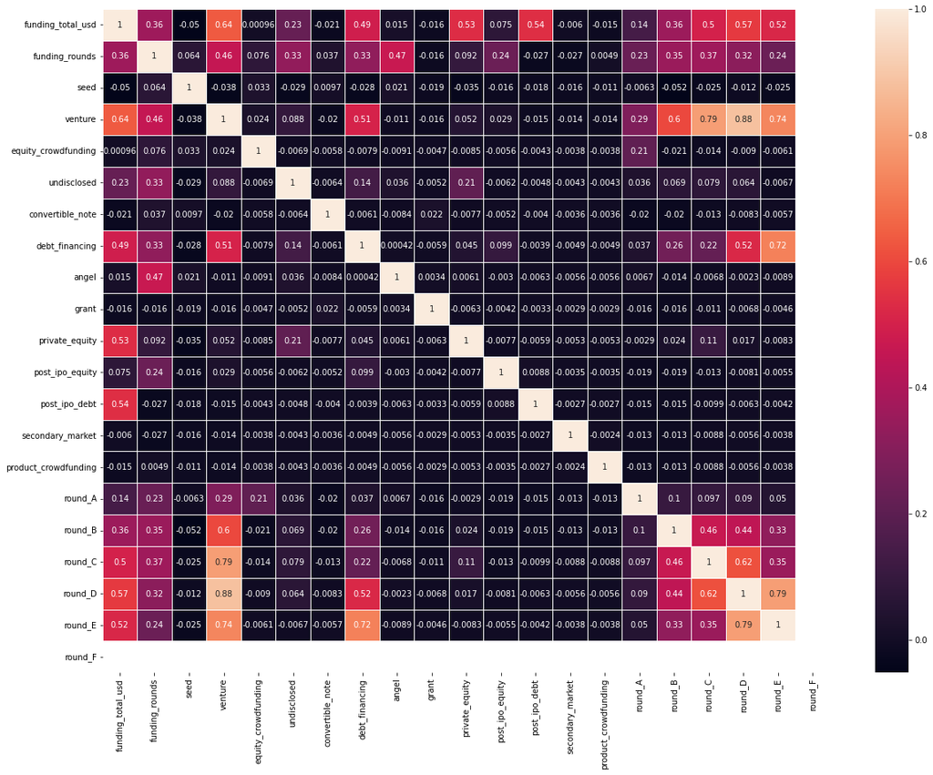

```python
plt.subplots(figsize=(20,15))

sns.heatmap(investments.corr(), annot=True, linewidth=0.5);

# This heat map provides a general overview of our investments data.
```

```python
# Ungroup dataset

investments = investments.reset_index(level=' market ')
```

```python
# The total number of startups in each sector of fintech

investments[' market '].value_counts()
```

```
 Financial Services     114
 Payments                79
 Finance Technology      64
 Mobile Payments         64
 Social Commerce         57
 Credit                  13
 P2P Money Transfer      11
 Monetization            10
 Credit Cards             9
Name:  market , dtype: int64
```

```python
# Status of startups based on market sector

operating = investments[investments.status == 'operating']
acquired = investments[investments.status == 'acquired']
closed = investments[investments.status == 'closed']
```

```python
operating_count  = operating[' market '].value_counts()
operating_count = operating_count[:10,]

print('Operating')
print(operating_count)
```

```
Operating
 Financial Services     101
 Payments                64
 Finance Technology      60
 Mobile Payments         58
 Social Commerce         49
 Credit                  11
 P2P Money Transfer      11
 Monetization             8
 Credit Cards             6
Name:  market , dtype: int64
```

```python
acquired_count  = acquired[' market '].value_counts()
acquired_count = acquired_count[:10,]

print('Acquired')
print(acquired_count)
```

```
Acquired
 Payments               11
 Financial Services      5
 Mobile Payments         5
 Social Commerce         4
 Finance Technology      2
 Monetization            2
 Credit                  1
Name:  market , dtype: int64
```

```python
closed_count  = closed[' market '].value_counts()
closed_count = closed_count[:10,]

print('Closed')
print(closed_count)
```

```
Closed
 Social Commerce        4
 Payments               3
 Credit Cards           2
 Financial Services     2
 Credit                 1
 Mobile Payments        1
Name:  market , dtype: int64
```

```python
# Startup status for each sector

startup = investments.groupby(' market ').status.value_counts()

startup
```

```
 market               status
 Credit               operating     11
                      acquired       1
                      closed         1
 Credit Cards         operating      6
                      closed         2
 Finance Technology   operating     60
                      acquired       2
 Financial Services   operating    101
                      acquired       5
                      closed         2
 Mobile Payments      operating     58
                      acquired       5
                      closed         1
 Monetization         operating      8
                      acquired       2
 P2P Money Transfer   operating     11
 Payments             operating     64
                      acquired      11
                      closed         3
 Social Commerce      operating     49
                      acquired       4
                      closed         4
Name: status, dtype: int64
```

## Fintech Status by Chart

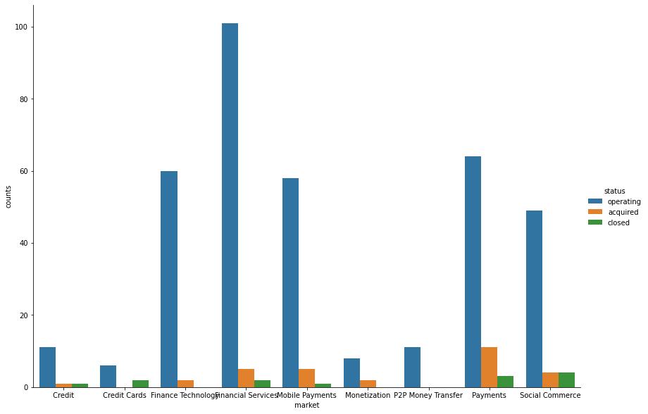

```python
# Startup status for each Fintech sector for bar plot
startup1 = investments.groupby(' market ').status.value_counts().reset_index(name='counts')
sns.catplot(x=" market ", y="counts", hue="status", kind="bar", data=startup1, height=8.27, aspect=11.7/8.27)
```

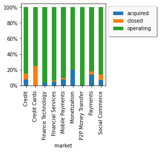

```python
# Relationship between operating, acquired and closed startups in each sector - normalised to a 100 percent bar chart

import matplotlib.ticker as mtick

investments.groupby([' market ','status']).size().groupby(level=0).apply(
    lambda x: 100 * x / x.sum()
).unstack().plot(kind='bar',stacked=True)

plt.gca().yaxis.set_major_formatter(mtick.PercentFormatter())
plt.legend(bbox_to_anchor=(1,1), frameon = True, fancybox = True, framealpha = 0.95, shadow = True,
           borderpad = 1)
plt.show()
```

```python
# Total number of Fintech startups per market/industry with more than 1 million USD investment

most_high= investments[[' market ', 'name']][investments['funding_total_usd'] > 1000000].groupby([' market '],
                                        as_index=False).count().sort_values('name', ascending=False)
most_high.head(20)
top20 = most_high.head(20)
top20
```

|  | market | name |
| --- | --- | --- |
| 3 | Financial Services | 57 |
| 7 | Payments | 50 |
| 4 | Mobile Payments | 32 |
| 2 | Finance Technology | 31 |
| 8 | Social Commerce | 19 |
| 0 | Credit | 10 |
| 5 | Monetization | 7 |
| 6 | P2P Money Transfer | 6 |
| 1 | Credit Cards | 4 |

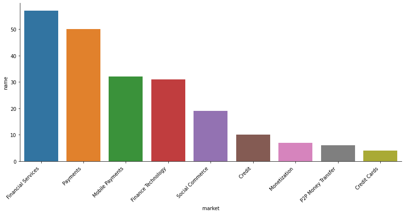

```python
Nordm = sns.catplot(x=" market ", y="name",  kind="bar", data=top20, height=5.27, aspect=11.7/5.27)
Nordm.set_xticklabels(rotation=45, horizontalalignment='right')
```

```python
# Total number of startups per US market with more than 1 million USD investment

us_high= investments[investments['country_code'] == 'USA']

ush = us_high[[' market ', 'name']][us_high['funding_total_usd'] > 1000000].groupby([' market '],
                                        as_index=False).count().sort_values('name', ascending=False)

usl10=ush.head(10)
usl10
```

|  | market | name |
| --- | --- | --- |
| 3 | Financial Services | 35 |
| 7 | Payments | 30 |
| 2 | Finance Technology | 20 |
| 4 | Mobile Payments | 15 |
| 8 | Social Commerce | 15 |
| 5 | Monetization | 6 |
| 0 | Credit | 5 |
| 1 | Credit Cards | 3 |
| 6 | P2P Money Transfer | 3 |

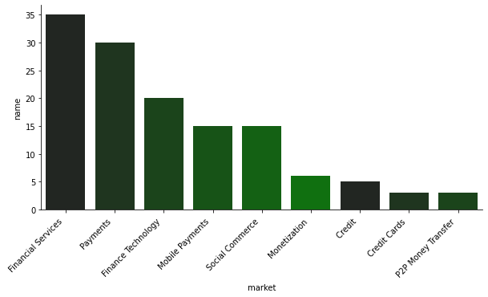

```python
usm = sns.catplot(x=" market ", y="name",  kind="bar", data=usl10, height=4.27, aspect=8.7/4.27,palette=sns.dark_palette("green"))
usm.set_xticklabels(rotation=45, horizontalalignment='right')
```

### **Funding Landscape**

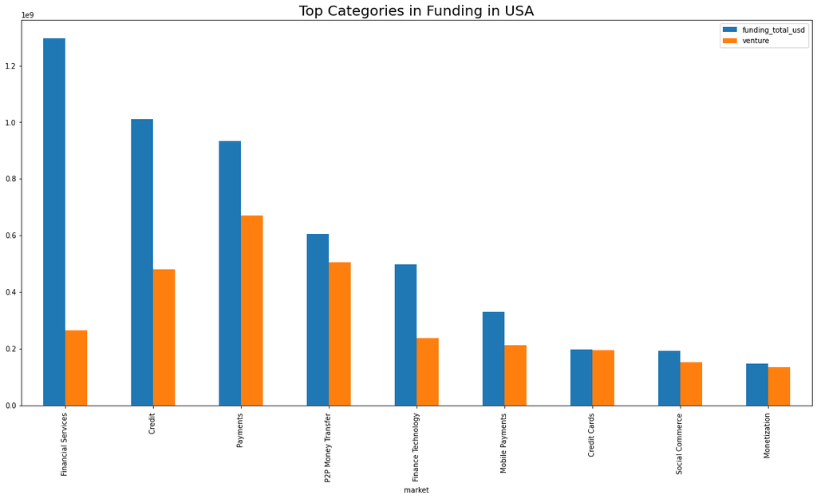

```python
# US Top 10 Categories in funding and venture
gbf=investments[(investments['country_code'] == 'USA')]

gg= gbf.groupby(' market ').sum()
LF = gg.nlargest(10,'funding_total_usd')
fg=LF.plot(kind ='bar', y=['funding_total_usd','venture'], figsize=(20,10))

fg.set_title('Top Categories in Funding in USA',fontsize=(20))
```

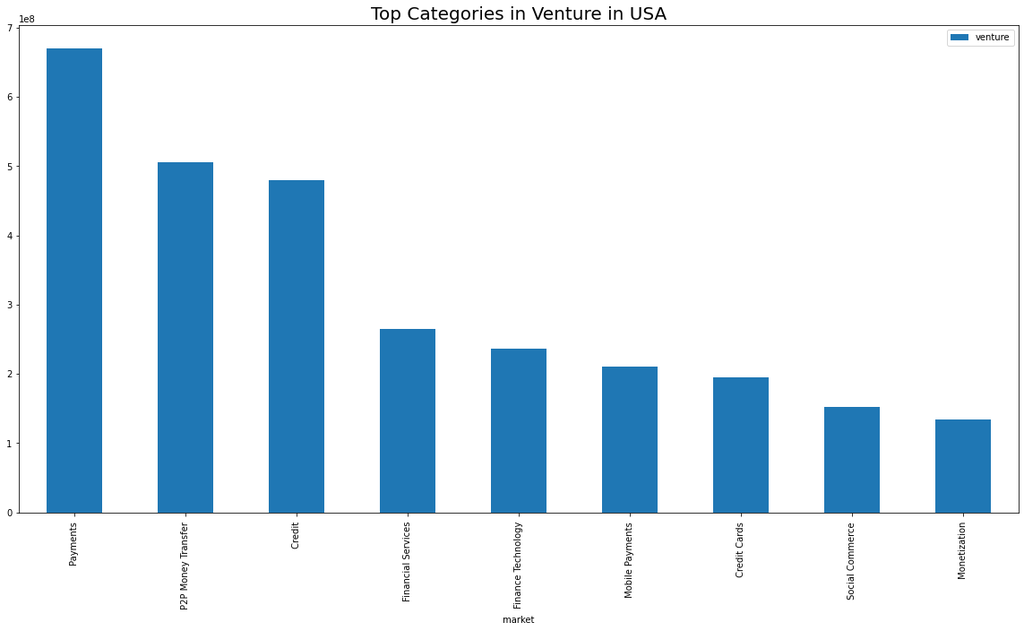

```python
# US Top 10 Categories in funding and venture
gbf=investments[(investments['country_code'] == 'USA')]

gg= gbf.groupby(' market ').sum()
LF = gg.nlargest(10,'venture')
fg=LF.plot(kind ='bar', y=['venture'], figsize=(20,10))

fg.set_title('Top Categories in Venture in USA',fontsize=(20))
```

```python
investments['funding_in_seed'] = investments['seed'].map(lambda x :1  if x > 0 else 0)
```

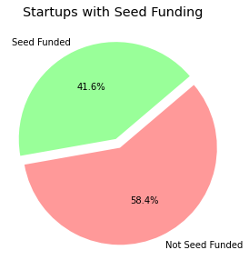

```python
plt.rcParams['figure.figsize'] =4,4
labels = ['Not Seed Funded','Seed Funded']
sizes = investments['funding_in_seed'].value_counts().tolist()
explode = (0, 0.1)
colors =  ['#ff9999','#99ff99']

plt.pie(sizes, explode = explode, colors = colors ,labels=labels, autopct='%1.1f%%',
        shadow=False, startangle=190)
plt.axis('equal')
plt.tight_layout()
plt.title("Startups with Seed Funding", fontdict=None, position= [0.48,1.1], size = 'x-large')

plt.show()
```

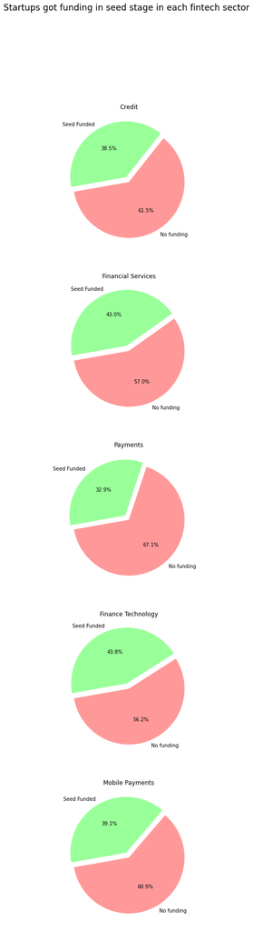

```python
grouped_by_sector = investments.groupby(' market ')
fin = grouped_by_sector.get_group(' Credit ')
ser = grouped_by_sector.get_group(' Financial Services ')
pay = grouped_by_sector.get_group(' Payments ')
tec = grouped_by_sector.get_group(' Finance Technology ')
mob = grouped_by_sector.get_group(' Mobile Payments ')

fig, ax = plt.subplots(nrows=5, ncols=1, figsize = (5,30))

labels = ['No funding','Seed Funded']
sizes_fin = fin['funding_in_seed'].value_counts().tolist()
sizes_ser = ser['funding_in_seed'].value_counts().tolist()
sizes_pay = pay['funding_in_seed'].value_counts().tolist()
sizes_tec = tec['funding_in_seed'].value_counts().tolist()
sizes_mob = mob['funding_in_seed'].value_counts().tolist()
explode = (0, 0.1)
colors =  ['#ff9999','#99ff99']

ax[0].set_title("Credit")
ax[0].pie(sizes_fin, explode = explode, colors = colors ,labels=labels, autopct='%1.1f%%',
        shadow=False, startangle=190)
ax[1].set_title("Financial Services")
ax[1].pie(sizes_ser, explode = explode, colors = colors ,labels=labels, autopct='%1.1f%%',
        shadow=False, startangle=190)
ax[2].set_title("Payments")
ax[2].pie(sizes_pay, explode = explode, colors = colors ,labels=labels, autopct='%1.1f%%',
        shadow=False, startangle=190)
ax[3].set_title("Finance Technology")
ax[3].pie(sizes_tec, explode = explode, colors = colors ,labels=labels, autopct='%1.1f%%',
        shadow=False, startangle=190)
ax[4].set_title("Mobile Payments")
ax[4].pie(sizes_mob, explode = explode, colors = colors ,labels=labels, autopct='%1.1f%%',
        shadow=False, startangle=190)
fig.suptitle('Startups got funding in seed stage in each fintech sector' , size = 'xx-large')
plt.show()
```

```python
investments['funding_vc'] = investments['venture'].map(lambda v :1  if v > 0 else 0)
```

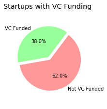

```python
plt.rcParams['figure.figsize'] =3,3
labels = ['Not VC Funded','VC Funded']
sizes = investments['funding_vc'].value_counts().tolist()
explode = (0, 0.1)
colors =  ['#ff9999','#99ff99']

plt.pie(sizes, explode = explode, colors = colors ,labels=labels, autopct='%1.1f%%',
        shadow=False, startangle=190)
plt.axis('equal')
plt.tight_layout()
plt.title("Startups with VC Funding", fontdict=None, position= [0.48,1.1], size = 'x-large')

plt.show()
```

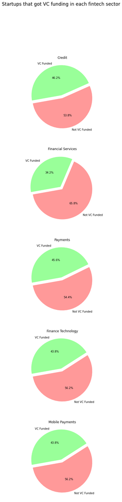

```python
grouped_by_sector = investments.groupby(' market ')
fin = grouped_by_sector.get_group(' Credit ')
ser = grouped_by_sector.get_group(' Financial Services ')
pay = grouped_by_sector.get_group(' Payments ')
tec = grouped_by_sector.get_group(' Finance Technology ')
mob = grouped_by_sector.get_group(' Mobile Payments ')

fig, ax = plt.subplots(nrows=5, ncols=1, figsize = (5,30))

labels = ['Not VC Funded','VC Funded']
sizes_fin = fin['funding_vc'].value_counts().tolist()
sizes_ser = ser['funding_vc'].value_counts().tolist()
sizes_pay = pay['funding_vc'].value_counts().tolist()
sizes_nor = tec['funding_vc'].value_counts().tolist()
sizes_mob = mob['funding_vc'].value_counts().tolist()
explode = (0, 0.1)
colors =  ['#ff9999','#99ff99']

ax[0].set_title("Credit")
ax[0].pie(sizes_fin, explode = explode, colors = colors ,labels=labels, autopct='%1.1f%%',
        shadow=False, startangle=190)
ax[1].set_title("Financial Services")
ax[1].pie(sizes_ser, explode = explode, colors = colors ,labels=labels, autopct='%1.1f%%',
        shadow=False, startangle=190)
ax[2].set_title("Payments")
ax[2].pie(sizes_pay, explode = explode, colors = colors ,labels=labels, autopct='%1.1f%%',
        shadow=False, startangle=190)
ax[3].set_title("Finance Technology")
ax[3].pie(sizes_tec, explode = explode, colors = colors ,labels=labels, autopct='%1.1f%%',
        shadow=False, startangle=190)
ax[4].set_title("Mobile Payments")
ax[4].pie(sizes_mob, explode = explode, colors = colors ,labels=labels, autopct='%1.1f%%',
        shadow=False, startangle=190)
fig.suptitle('Startups that got VC funding in each fintech sector' , size = 'xx-large')
plt.show()
```

```python
# Total number of values and sum of each round (A - F)

print('Total number of values in round_A: ', len(investments[investments['round_A'] != 0]))
print('Sum of round_A: $', investments['round_A'].sum())
print('Avg. round_A: $', round(investments['round_A'].sum()/len(investments[investments['round_A'] != 0]),2))
print('')
print('Total number of values in round_B: ', len(investments[investments['round_B'] != 0]))
print('Sum of round_B: $', investments['round_B'].sum())
print('Avg. round_B: $', round(investments['round_B'].sum()/len(investments[investments['round_B'] != 0]),2))
print('')
print('Total number of values in round_C: ', len(investments[investments['round_C'] != 0]))
print('Sum of round_C: $', investments['round_C'].sum())
print('Avg. round_C: $', round(investments['round_C'].sum()/len(investments[investments['round_C'] != 0]),2))
print('')
print('Total number of values in round_D: ', len(investments[investments['round_D'] != 0]))
print('Sum of round_D: $', investments['round_D'].sum())
print('Avg. round_D: $', round(investments['round_D'].sum()/len(investments[investments['round_D'] != 0]),2))
print('')
print('Total number of values in round_E: ', len(investments[investments['round_E'] != 0]))
print('Sum of round_E: $', investments['round_E'].sum())
print('Avg. round_E: $', round(investments['round_E'].sum()/len(investments[investments['round_E'] != 0]),2))
print('')
print('Total number of values in round_F: ', len(investments[investments['round_F'] != 0]))
print('Sum of round_F: $', investments['round_F'].sum())
print('Avg. round_F: $', round(investments['round_F'].sum()/len(investments[investments['round_F'] != 0]),2))
```

```
Total number of values in round_A:  88
Sum of round_A: $ 745972600.0
Avg. round_A: $ 8476961.36

Total number of values in round_B:  39
Sum of round_B: $ 529230261.0
Avg. round_B: $ 13570006.69

Total number of values in round_C:  28
Sum of round_C: $ 1021581452.0
Avg. round_C: $ 36485051.86

Total number of values in round_D:  11
Sum of round_D: $ 587050003.0
Avg. round_D: $ 53368182.09

Total number of values in round_E:  4
Sum of round_E: $ 270780013.0
Avg. round_E: $ 67695003.25

Total number of values in round_F:  0
Sum of round_F: $ 0.0
Avg. round_F: $ nan
```

### **Competitive Landscape**

```python
# Top 20 funded startups & companies

most_funded = investments.nlargest(20, ['funding_total_usd'])
most_funded
```

|  | market | name | funding_total_usd | status | country_code | region | state_code | funding_rounds | founded_at | first_funding_at | last_funding_at | seed | venture | equity_crowdfunding | undisclosed | convertible_note | debt_financing | angel | grant | private_equity | post_ipo_equity | post_ipo_debt | secondary_market | product_crowdfunding | round_A | round_B | round_C | round_D | round_E | … |
| --- | --- | --- | --- | --- | --- | --- | --- | --- | --- | --- | --- | --- | --- | --- | --- | --- | --- | --- | --- | --- | --- | --- | --- | --- | --- | --- | --- | --- | --- | --- |
| 109 | Financial Services | Compass Diversified Holdings | 725000000.0 | operating | USA | Hartford | CT | 1.0 | NaT | 2014-06-09 | 2014-06-09 | 0.0 | 0.0 | 0.0 | 0.0 | 0.0 | 0.0 | 0.0 | 0.0 | 0.0 | 0.0 | 725000000.0 | 0.0 | 0.0 | 0.0 | 0.0 | 0.0 | 0.0 | 0.0 | … |
| 281 | P2P Money Transfer | Square | 590500000.0 | operating | USA | SF Bay Area | CA | 7.0 | 2009-02-01 | 2009-11-01 | 2014-10-05 | 0.0 | 490500000.0 | 0.0 | 0.0 | 0.0 | 100000000.0 | 0.0 | 0.0 | 0.0 | 0.0 | 0.0 | 0.0 | 0.0 | 10000000.0 | 27500000.0 | 103000000.0 | 200000000.0 | 150000000.0 | … |
| 52 | Finance Technology | Hundsun Technologies | 532000000.0 | operating | NaN | NaN | NaN | 1.0 | 1995-02-01 | 2014-04-02 | 2014-04-02 | 0.0 | 0.0 | 0.0 | 0.0 | 0.0 | 0.0 | 0.0 | 0.0 | 532000000.0 | 0.0 | 0.0 | 0.0 | 0.0 | 0.0 | 0.0 | 0.0 | 0.0 | 0.0 | … |
| 10 | Credit | OnDeck | 409000000.0 | operating | USA | New York City | NY | 8.0 | 2007-01-01 | 2006-01-01 | 2014-03-06 | 0.0 | 179000000.0 | 0.0 | 0.0 | 0.0 | 230000000.0 | 0.0 | 0.0 | 0.0 | 0.0 | 0.0 | 0.0 | 0.0 | 2000000.0 | 16000000.0 | 25000000.0 | 59000000.0 | 77000000.0 | … |
| 9 | Credit | Lending Club | 392230000.0 | operating | USA | SF Bay Area | CA | 12.0 | 2007-01-01 | 2007-05-01 | 2014-04-17 | 0.0 | 93230000.0 | 0.0 | 57000000.0 | 0.0 | 50000000.0 | 2000000.0 | 0.0 | 190000000.0 | 0.0 | 0.0 | 0.0 | 0.0 | 10260000.0 | 12000000.0 | 24500000.0 | 25000000.0 | 0.0 | … |
| 323 | Payments | Klarna | 282074000.0 | operating | SWE | Stockholm | NaN | 6.0 | 2005-02-11 | 2005-01-01 | 2014-03-14 | 0.0 | 166200000.0 | 0.0 | 0.0 | 0.0 | 0.0 | 80000.0 | 0.0 | 115794000.0 | 0.0 | 0.0 | 0.0 | 0.0 | 2200000.0 | 9000000.0 | 155000000.0 | 0.0 | 0.0 | … |
| 43 | Finance Technology | Freedom Financial Network | 235000000.0 | operating | USA | SF Bay Area | CA | 2.0 | 2002-01-01 | 2013-12-11 | 2014-05-05 | 0.0 | 0.0 | 0.0 | 0.0 | 0.0 | 0.0 | 0.0 | 0.0 | 235000000.0 | 0.0 | 0.0 | 0.0 | 0.0 | 0.0 | 0.0 | 0.0 | 0.0 | 0.0 | … |
| 339 | Payments | PayPal | 197000000.0 | acquired | USA | SF Bay Area | CA | 5.0 | 1998-12-01 | 1999-01-01 | 2001-02-16 | 0.0 | 197000000.0 | 0.0 | 0.0 | 0.0 | 0.0 | 0.0 | 0.0 | 0.0 | 0.0 | 0.0 | 0.0 | 0.0 | 0.0 | 4000000.0 | 100000000.0 | 90000000.0 | 0.0 | … |
| 3 | Credit | Credit Karma | 193000000.0 | operating | USA | SF Bay Area | CA | 5.0 | 2007-06-01 | 2008-10-15 | 2014-09-29 | 0.0 | 192500000.0 | 0.0 | 0.0 | 0.0 | 0.0 | 500000.0 | 0.0 | 0.0 | 0.0 | 0.0 | 0.0 | 0.0 | 2500000.0 | 30000000.0 | 85000000.0 | 75000000.0 | 0.0 | … |
| 20 | Credit Cards | Stripe | 190000000.0 | operating | USA | SF Bay Area | CA | 5.0 | 2010-01-01 | 2010-08-02 | 2014-01-22 | 2000000.0 | 188000000.0 | 0.0 | 0.0 | 0.0 | 0.0 | 0.0 | 0.0 | 0.0 | 0.0 | 0.0 | 0.0 | 0.0 | 18000000.0 | 20000000.0 | 80000000.0 | 70000000.0 | 0.0 | … |
| 292 | Payments | BlueSnap | 165000000.0 | operating | USA | Boston | MA | 2.0 | 2002-03-15 | 2011-09-01 | 2014-11-04 | 0.0 | 0.0 | 0.0 | 0.0 | 0.0 | 0.0 | 0.0 | 0.0 | 165000000.0 | 0.0 | 0.0 | 0.0 | 0.0 | 0.0 | 0.0 | 0.0 | 0.0 | 0.0 | … |
| 226 | Mobile Payments | Net Element | 127700000.0 | operating | USA | Miami | FL | 9.0 | 2004-01-10 | 2012-04-29 | 2014-09-23 | 0.0 | 34000000.0 | 0.0 | 0.0 | 0.0 | 30000000.0 | 0.0 | 0.0 | 0.0 | 53700000.0 | 10000000.0 | 0.0 | 0.0 | 0.0 | 0.0 | 0.0 | 0.0 | 0.0 | … |
| 182 | Financial Services | Strategic Funding Source | 110000000.0 | operating | USA | New York City | NY | 1.0 | NaT | 2014-09-03 | 2014-09-03 | 0.0 | 0.0 | 0.0 | 0.0 | 0.0 | 0.0 | 0.0 | 0.0 | 110000000.0 | 0.0 | 0.0 | 0.0 | 0.0 | 0.0 | 0.0 | 0.0 | 0.0 | 0.0 | … |
| 217 | Mobile Payments | iZettle | 108520072.0 | operating | SWE | Stockholm | NaN | 4.0 | 2010-04-01 | 2011-10-18 | 2014-07-14 | 0.0 | 108520072.0 | 0.0 | 0.0 | 0.0 | 0.0 | 0.0 | 0.0 | 0.0 | 0.0 | 0.0 | 0.0 | 0.0 | 15317120.0 | 31400000.0 | 61802952.0 | 0.0 | 0.0 | … |
| 290 | Payments | Bill Me Later | 100000000.0 | acquired | USA | Baltimore | MD | 3.0 | 2000-01-01 | 2006-03-01 | 2007-12-01 | 0.0 | 100000000.0 | 0.0 | 0.0 | 0.0 | 0.0 | 0.0 | 0.0 | 0.0 | 0.0 | 0.0 | 0.0 | 0.0 | 100000000.0 | 0.0 | 0.0 | 0.0 | 0.0 | … |
| 345 | Payments | Qufenqi | 100000000.0 | operating | CHN | Beijing | NaN | 2.0 | NaT | 2014-08-15 | 2014-12-02 | 0.0 | 100000000.0 | 0.0 | 0.0 | 0.0 | 0.0 | 0.0 | 0.0 | 0.0 | 0.0 | 0.0 | 0.0 | 0.0 | 0.0 | 0.0 | 100000000.0 | 0.0 | 0.0 | … |
| 123 | Financial Services | euNetworks Group Limited | 88205645.0 | operating | DEU | Frankfurt | NaN | 1.0 | NaT | 2014-10-03 | 2014-10-03 | 0.0 | 0.0 | 0.0 | 0.0 | 0.0 | 0.0 | 0.0 | 0.0 | 0.0 | 0.0 | 88205645.0 | 0.0 | 0.0 | 0.0 | 0.0 | 0.0 | 0.0 | 0.0 | … |
| 285 | Payments | 99Bill | 81574271.0 | operating | CHN | Shanghai | NaN | 4.0 | 2005-01-01 | 2006-04-26 | 2012-12-14 | 0.0 | 81574271.0 | 0.0 | 0.0 | 0.0 | 0.0 | 0.0 | 0.0 | 0.0 | 0.0 | 0.0 | 0.0 | 0.0 | 0.0 | 15050000.0 | 0.0 | 0.0 | 27000013.0 | … |
| 145 | Financial Services | LearnVest | 69030000.0 | operating | USA | New York City | NY | 5.0 | 2007-05-01 | 2009-08-31 | 2014-04-15 | 1100000.0 | 67930000.0 | 0.0 | 0.0 | 0.0 | 0.0 | 0.0 | 0.0 | 0.0 | 0.0 | 0.0 | 0.0 | 0.0 | 4430000.0 | 19000000.0 | 16500000.0 | 28000000.0 | 0.0 | … |
| 289 | Payments | Arroweye Solutions | 58900000.0 | operating | USA | Chicago | IL | 7.0 | 1999-01-01 | 2000-03-31 | 2012-06-25 | 0.0 | 14000000.0 | 0.0 | 43400000.0 | 0.0 | 1500000.0 | 0.0 | 0.0 | 0.0 | 0.0 | 0.0 | 0.0 | 0.0 | 0.0 | 0.0 | 14000000.0 | 0.0 | 0.0 | … |

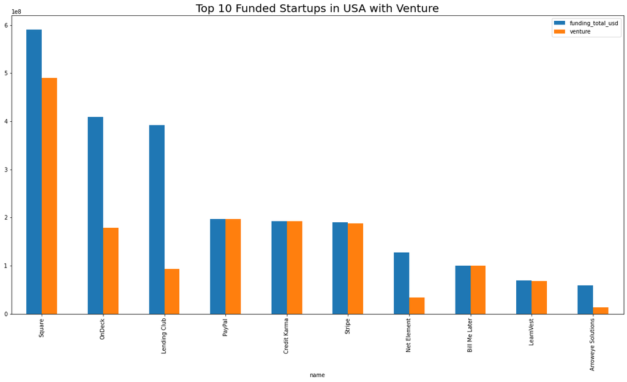

```python
# US Top 10 largest VC-funded fintech startups
gbf=investments[(investments['country_code'] == 'USA')]
gbu=gbf[(gbf['venture'] > 0)]

gg= gbu.groupby('name').sum()
LF = gg.nlargest(10,'funding_total_usd')
fg=LF.plot(kind ='bar', y=['funding_total_usd','venture'], figsize=(20,10))

fg.set_title('Top 10 Funded Startups in USA with Venture',fontsize=(20))
```